# Biogeografia: áreas e reconstruções

Marcelo Reginato

Bioinformática aplicada à sistemática, biogeografia e macroevolução

Novembro / 2018

## Pacotes necessários

Para este tutorial nós iremos utilizar funções dos seguintes pacotes:

```r
install.packages("rexpokit", dependencies=T)
install.packages("cladoRcpp", dependencies=T)
install.packages("devtools", dependencies=T)
install.packages("dismo", dependencies=T)
install.packages("geojsonio", dependencies=T)
install.packages("scales", dependencies=T)
install.packages("parallel", dependencies=T)
install.packages("phyloclim", dependencies=T)
```

Instalando BioGeoBEARS do github.

```r
library(devtools)
devtools::install_github(repo="nmatzke/BioGeoBEARS")
```

Carregando os pacotes.

```r
library(ape)
library(phyloch)
library(raster)
library(dismo)
library(maptools)
library(rgdal)
library(monographaR)
library(rgeos)
library(geojsonio)
library(scales)
library(BioGeoBEARS)
library(parallel)
library(optimx)
library(phyloclim)
```

## Importando os dados

Importando os pontos e a árvore de Lychnophora

```r
### Mude o seu working directory

setwd("~/Post-doc-Unicamp/Bioinformatica/Aulas/9 - BioGeoBEARS")
getwd() -> wd
```

Importando os dados

```r
### Importando os pontos
read.table("Lychnophora_xy.txt", header = T) -> xy
head(xy)
```

```
##                  species       lon       lat
## 1 Lychnophora markgravii -42.88970 -16.55940
## 2 Lychnophora markgravii -44.17220 -17.75750
## 3 Lychnophora markgravii -42.88970 -16.55940
## 4 Lychnophora markgravii -44.19194 -17.70750
## 5 Lychnophora markgravii -44.26250 -17.69833
## 6 Lychnophora markgravii -42.58333 -16.41667
```

## Ranges

Vamos utilizar duas funções para recuperar as ranges.

```r
### Carregando as funções
source("https://raw.githubusercontent.com/mreginato/Bioinformatica_aplicada_a_sistematica_biogeografia_e_macroevolucao/master/Functions/rangeShape.R")
source("https://raw.githubusercontent.com/mreginato/Bioinformatica_aplicada_a_sistematica_biogeografia_e_macroevolucao/master/Functions/rangeShapeElevation.R")
```

### Preparando os dados

A função “rangeShape” executa o mesmo procedimento que vimos anteriormente para extrair polígonos a partir do modelo de distribuição, pontos de distribuição e um valor de threshold. Enquanto que a função “rangeShapeElevation” utiliza os pontos de distribuição, um buffer e remove áreas dentro do polígono resultando com base na altitude.  
Primeiro vamos importar os valores de AUC e os thresholds de todos os modelos. Daí iremos dividir os dados em “good” e “failure” (i.e., quando a AUC do modelo for menor que um determinado valor).

```r
read.table("thresholds.txt") -> thresholds
read.table("evaluations.txt") -> evaluations

head(evaluations)
```

```
##                                  AUC        cor
## Lychnophora bishopii       0.9913302 0.16500529
## Lychnophora crispa         0.9970507 0.18386182
## Lychnophora diamantinana   0.9965076 0.13124720
## Lychnophora ericoides      0.9616482 0.17693808
## Lychnophora gardneri       0.9750432 0.08060857
## Lychnophora granmogolensis 0.9771539 0.20044418
```

```r
head(thresholds)
```

```
##                                kappa spec_sens no_omission prevalence
## Lychnophora bishopii       0.9919651 0.2895082  0.28950824 0.00060995
## Lychnophora crispa         0.9999967 0.7134674  0.71346738 0.00040571
## Lychnophora diamantinana   0.9962983 0.7523514  0.75235136 0.00030639
## Lychnophora ericoides      0.9746553 0.3191301  0.12327358 0.00283173
## Lychnophora gardneri       0.9949362 0.3466799  0.34667991 0.00040171
## Lychnophora granmogolensis 0.9996475 0.2434237  0.06671721 0.00152059
##                            equal_sens_spec sensitivity
## Lychnophora bishopii             0.2895082   0.2965392
## Lychnophora crispa               0.7134674   0.7155096
## Lychnophora diamantinana         0.7523514   0.7762376
## Lychnophora ericoides            0.3202025   0.3202025
## Lychnophora gardneri             0.3466799   0.3492501
## Lychnophora granmogolensis       0.1940081   0.2477271
```

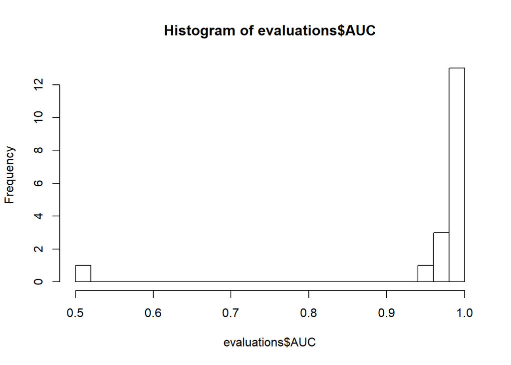

```r
thresholds[,-c(3,4)] -> thresholds
rowMeans(thresholds) -> thresholds$mean

hist(evaluations$AUC, breaks=20)
```

```r
### Usei media para todos

fail.auc = 0.9

evaluations$AUC -> e
which(e < fail.auc) -> fail
length(fail)/length(e)
```

```
## [1] 0.05555556
```

```r
which(e >= fail.auc) -> good

rownames(evaluations)[good] -> good.spp
rownames(evaluations)[fail] -> fail.spp

sort(good.spp) -> good.spp
sort(fail.spp) -> fail.spp

as.matrix(thresholds) -> thresholds
thresholds[which(thresholds > 1)] <- 1
as.data.frame(thresholds) -> thresholds

thresholds$mean[match(good.spp, rownames(thresholds))] -> threshs.good
names(threshs.good) <- good.spp

xy[which(is.na(match(xy$species, good.spp)) == F),] -> data.good
xy[which(is.na(match(xy$species, fail.spp)) == F),] -> data.fail
```

### rangeShape

Rodar a função para as espécies com bons AUC.

```r
### Diretorios de input / output
asc_in <- "~/Post-doc-Unicamp/Bioinformatica/Aulas/9 - BiogeoBEARS/Rasters"
out_shape <- "~/Post-doc-Unicamp/Bioinformatica/Aulas/9 - BiogeoBEARS/Ranges"

### Good models

rangeShape(data.good, out_shape, asc_in, thresholds=threshs.good, buffer.extent=3, overlay=T, format=".tif")
```

### rangeShapeElevation

Rodar a outra função para os modelos com AUC ruins.

```r
### Primeiro vamos importar um raster de elevação
raster("alt.tif") -> alt

### Failed models

rangeShapeElevation(data.fail, out_shape, elevation=alt, buffer.elevation=200, buffer.circle=30, format=".tif", overlay=T, fill.holes=F)
```

### Plot

```
##
 1OGR data source with driver: ESRI Shapefile
```

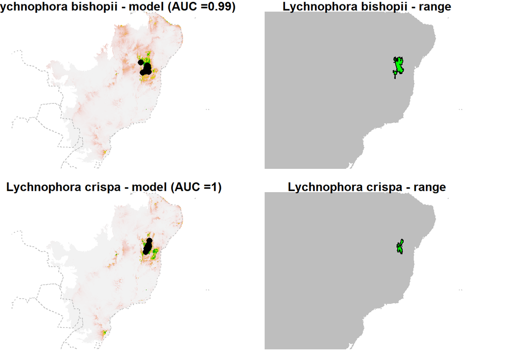

```
##
 2
```

Exportar plots das projeções e as ranges.

```r
out_plots <- "~/Post-doc-Unicamp/Bioinformatica/Aulas/9 - BiogeoBEARS/Plots"


setwd(out_shape)

sub(".shp", "", list.files(pattern=".shp")) -> spp

data("wrld_simpl")

for (i in 1:length(spp)) {
  spp[i] -> sp0
  xy[which(xy$species == sp0),-1] -> occ
  round(evaluations$AUC[which(rownames(evaluations) == sp0)],2) -> e0
  coordinates(occ) <- ~ lon + lat
  setwd(out_shape)
  readOGR(paste(sp0, ".shp", sep="")) -> poly0
  setwd(asc_in)
  raster(paste(sp0, ".tif", sep="")) -> r0
  setwd(out_plots)
  jpeg(filename=paste(sp0, ".jpg", sep=""), width=10, height=5, units="in", res=200)
  par(mfrow=c(1,2), mar=c(1,1,1,1))
  plot(r0, axes=F, box=F, legend=F)
  plot(wrld_simpl, add=T, border="gray", lty="dotted")
  plot(occ, pch=16, add=T, cex=1.3)
  title(paste(sp0, " - model (AUC =", e0, ")", sep=""))
  plot(r0, col="white", axes=F, box=F, legend=F)
  plot(wrld_simpl, add=T, col="gray", border="gray", lty="dotted")
  plot(poly0, col="green", add=T)
  title(paste(sp0, "- range"))
  dev.off()
  cat("\r", i)
}

setwd(wd)
```

### Shapefile

Combinar as ranges em um único shapefile

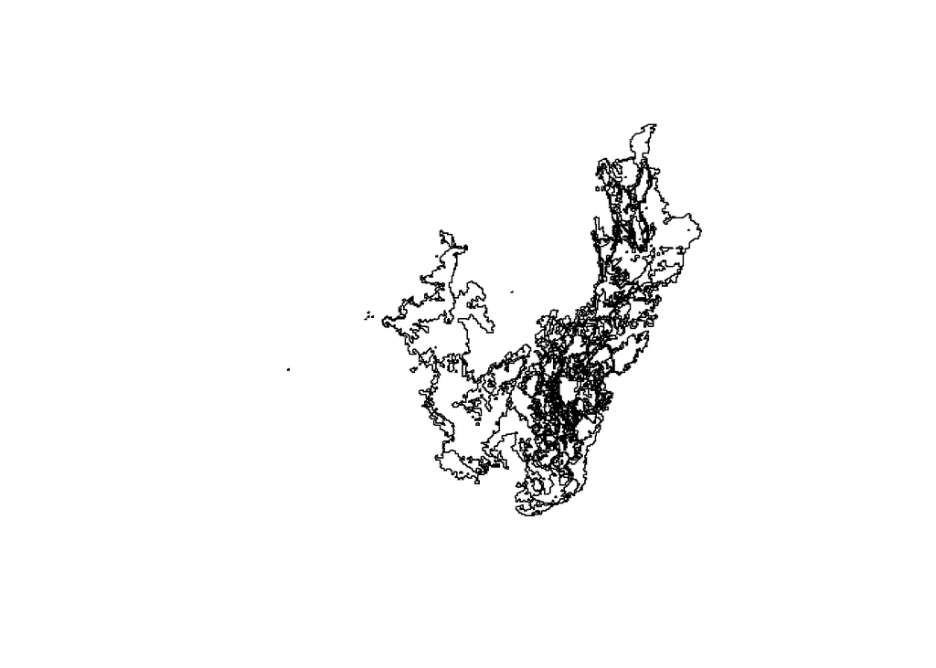

```r
setwd(out_shape)

list.files(pattern=".shp") -> files
sapply(files, readOGR, simplify = F) -> shapes
do.call(rbind, shapes) -> shapes
sub(".shp", "", files) -> shapes$spp

setwd(wd)

plot(shapes)

### Exportar

writeSpatialShape(shapes, "Lychnophora.shp")
```

## Richness

De posse dos polígonos, é possível gerar um mapa de riqueza.

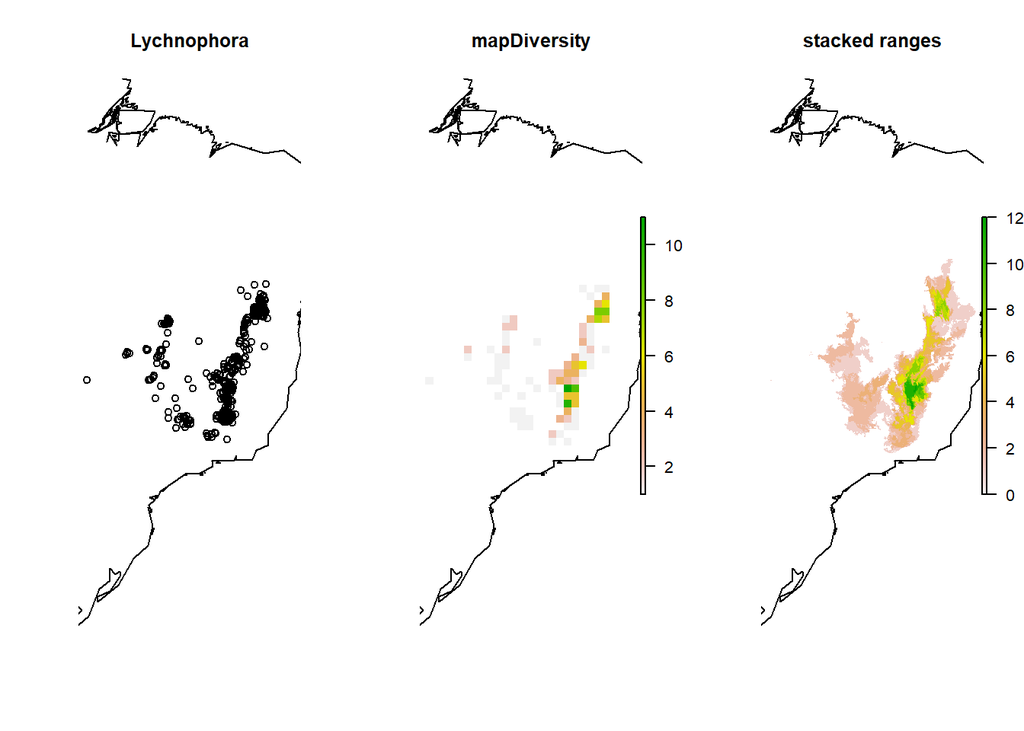

```r
### Criar uma "mask"

gUnaryUnion(shapes) -> lyc.mask

### Diversity

raster(res=0.05) -> lyc.r
lyc.r[] <- 0
crop(lyc.r, lyc.mask) -> lyc.r
lyc.r -> lyc.div

for (i in 1:nrow(shapes)) {
  shapes[i,] -> s0
  rasterize(s0, lyc.r) -> r0
  r0[is.na(r0)] <- 0
  sum(lyc.div, r0, na.rm = F) -> lyc.div
}

mask(lyc.div, lyc.mask) -> lyc.div

### export

writeRaster(lyc.div, "Lychnophora_richness.tif", overwrite=T)


### Comparar com "mapDiveristy"

mapDiversity(xy, resolution = 0.5, plot=F) -> mapdiv.out

par(mfrow=c(1,3))
plot(lyc.mask, border="white")
plot(wrld_simpl, add=T)
points(xy$lon, xy$lat, pch=21)
title("Lychnophora")
plot(lyc.mask, border="white")
plot(wrld_simpl, add=T)
plot(mapdiv.out, add=T)
title("mapDiversity")
plot(lyc.mask, border="white")
plot(wrld_simpl, add=T)
plot(lyc.div, add=T)
title("stacked ranges")
```

## Areas

Existem diversos métodos para delinear áreas biogeográficas. Vamos utilizar um método baseado em networks, e utilizar o shapefile com todas as ranges como input para esta análise. Está análise está disponível para rodar em um servidor online:

http://bioregions.mapequation.org/

Eu rodei a análise com os seguintes parâmetros:

- Max cell size = 2
- Min cell size = 1/2
- Max cell capacity = 100
- Min cell capacity = 1

### Importando as áreas

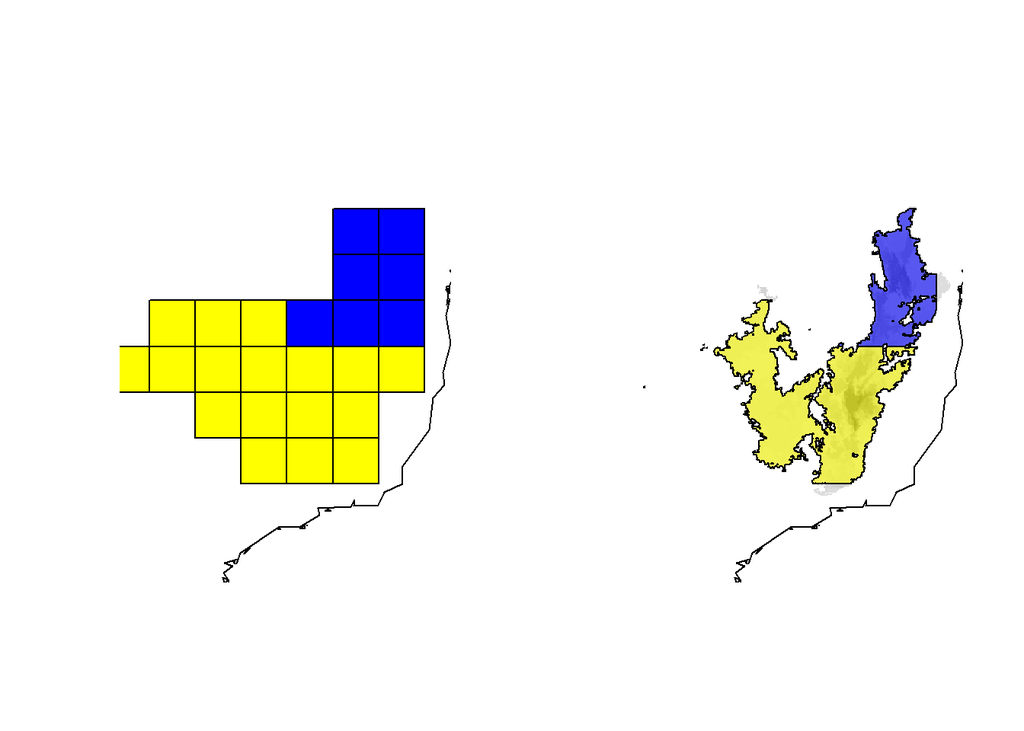

```r
geojson_read("Lychnophora_bioregions.geojson", what="sp") -> net.1

area.cols = c("yellow", "blue")

vector("list", length=nrow(net.1)) -> net.1.c

for (i in 1:nrow(net.1)) {
  net.1[i,] -> s0
  gUnaryUnion(s0) -> s0
  crop(s0, lyc.mask) -> s0
  SpatialPolygonsDataFrame(s0, data=net.1@data[i,], match.ID = F) -> s0
  s0 -> net.1.c[[i]]
}
do.call(rbind, net.1.c) -> net.1.c

par(mfrow=c(1,2))
plot(lyc.mask, border="white")
plot(net.1, col=area.cols, add=T)
plot(wrld_simpl, add=T)

plot(lyc.mask, border="white")
plot(lyc.div, col=rev(gray.colors(250)), add=T, legend=F)
plot(net.1.c, col=alpha(area.cols, 0.6), add=T)
plot(wrld_simpl, add=T)
```

```r
### Exportando

writeSpatialShape(net.1.c, "Lychnophora_areas.shp")
```

### Matriz

Construindo a matriz de presência / ausência.

```r
mapTable(xy, type="user", layer=net.1.c) -> lyc.mat
lyc.mat$bioregion -> lyc.mat
lyc.mat[lyc.mat == ""] <- 0
lyc.mat[lyc.mat == "x"] <- 1
mode(lyc.mat) <- "numeric"
lyc.mat
```

```
##                             bioregion
## species                      1 2
##   Lychnophora bishopii       0 1
##   Lychnophora crispa         0 1
##   Lychnophora diamantinana   1 0
##   Lychnophora ericoides      1 1
##   Lychnophora gardneri       1 0
##   Lychnophora granmogolensis 1 1
##   Lychnophora humillima      1 0
##   Lychnophora markgravii     1 0
##   Lychnophora passerina      1 1
##   Lychnophora pinaster       1 0
##   Lychnophora ramosissima    1 0
##   Lychnophora regis          0 1
##   Lychnophora salicifolia    1 1
##   Lychnophora santosii       0 1
##   Lychnophora sellowii       1 0
##   Lychnophora tomentosa      1 0
##   Lychnophora triflora       0 1
##   Lychnophora villosissima   1 0
```

```r
colSums(lyc.mat)
```

```
##  1  2
## 13  9
```

```r
### Export

write.table(lyc.mat, file="Lychnophora_matrix.txt")
```

## BioGeoBEARS

O pacote BioGeoBEARS tem um wiki com uma série de tutoriais:

http://phylo.wikidot.com/biogeobears

### Preparando os dados

Importando os dados

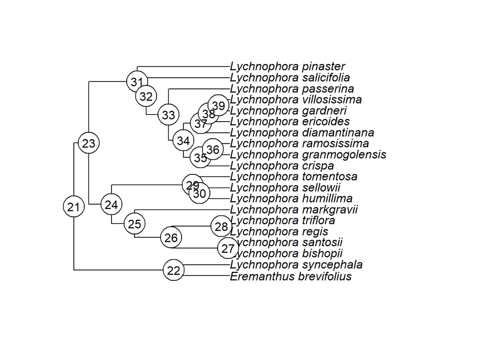

```r
### Importando a árvore

read.nexus("concatenated.tre") -> tree

### Removendo o outgroup
plot(tree)
nodelabels(frame="circ", bg="white")
```

```r
extract.clade(tree, node=23) -> tree
ladderize(tree) -> tree
fixNodes(tree) -> tree

### Exportando a árvore em formato newick

write.tree(tree, "Lychnophora_newick.tre")

### Importando a matriz

read.table("Lychnophora_matrix.txt") -> lyc.mat
colnames(lyc.mat) <- LETTERS[1:ncol(lyc.mat)]

### checkar spp matrix / arvore

sub(" ", "_", rownames(lyc.mat)) -> rownames(lyc.mat)

lyc.mat[tree$tip.label,] -> lyc.mat
rownames(lyc.mat) -> spp.dat
tree$tip.label -> spp.tree

spp.tree == spp.dat
```

```
##  [1] TRUE TRUE TRUE TRUE TRUE TRUE TRUE TRUE TRUE TRUE TRUE TRUE TRUE TRUE
## [15] TRUE TRUE TRUE TRUE
```

```r
### Exportar a matriz em formato phylip

define_tipranges_object(lyc.mat) -> lyc.phylip
save_tipranges_to_LagrangePHYLIP(lyc.phylip, lgdata_fn = "Lychnophora_phylip.txt")
```

```
## [1] "Lychnophora_phylip.txt"
```

### Setup geral

```r
trfn = "Lychnophora_newick.tre"
geogfn = "Lychnophora_phylip.txt"

tipranges = getranges_from_LagrangePHYLIP(lgdata_fn=geogfn)

max_range_size = 2
n.cores = 3
```

### DEC

Configurando para rodar o modelo DEC

```r
# Crie um modelo default
BioGeoBEARS_run_object = define_BioGeoBEARS_run()
BioGeoBEARS_run_object$trfn = trfn
BioGeoBEARS_run_object$geogfn = geogfn
BioGeoBEARS_run_object$max_range_size = max_range_size


# Opções de processamento
BioGeoBEARS_run_object$speedup = F
BioGeoBEARS_run_object$use_optimx = TRUE     # if FALSE, use optim() instead of optimx()
BioGeoBEARS_run_object$num_cores_to_use = n.cores

# Good default settings to get ancestral states
BioGeoBEARS_run_object$return_condlikes_table = TRUE
BioGeoBEARS_run_object$calc_TTL_loglike_from_condlikes_table = TRUE
BioGeoBEARS_run_object$calc_ancprobs = TRUE    # get ancestral states from optim run

# Conferir se está tudo certo com os inputs
check_BioGeoBEARS_run(BioGeoBEARS_run_object)
```

```
## [1] TRUE
```

```r
# Conferir o modelo
BioGeoBEARS_run_object$BioGeoBEARS_model_object@params_table
```

```
##          type    init      min      max     est                note
## d        free 0.01000  1.0e-12  5.00000 0.01000               works
## e        free 0.01000  1.0e-12  5.00000 0.01000               works
## a       fixed 0.00000  1.0e-12  5.00000 0.00000               works
## b       fixed 1.00000  1.0e-12  1.00000 1.00000 non-stratified only
## x       fixed 0.00000 -2.5e+00  2.50000 0.00000               works
## n       fixed 0.00000 -1.0e+01 10.00000 0.00000               works
## w       fixed 1.00000 -1.0e+01 10.00000 1.00000               works
## u       fixed 0.00000 -1.0e+01 10.00000 0.00000               works
## j       fixed 0.00000  1.0e-05  2.99999 0.00000               works
## ysv       3-j 2.99999  1.0e-05  3.00000 2.99999               works
## ys    ysv*2/3 1.99999  1.0e-05  2.00000 1.99999               works
## y     ysv*1/3 1.00000  1.0e-05  1.00000 1.00000               works
## s     ysv*1/3 1.00000  1.0e-05  1.00000 1.00000               works
## v     ysv*1/3 1.00000  1.0e-05  1.00000 1.00000               works
## mx01    fixed 0.00010  1.0e-04  0.99990 0.00010               works
## mx01j    mx01 0.00010  1.0e-04  0.99990 0.00010               works
## mx01y    mx01 0.00010  1.0e-04  0.99990 0.00010               works
## mx01s    mx01 0.00010  1.0e-04  0.99990 0.00010               works
## mx01v    mx01 0.00010  1.0e-04  0.99990 0.00010               works
## mx01r   fixed 0.50000  1.0e-04  0.99990 0.50000                  no
## mf      fixed 0.10000  5.0e-03  0.99500 0.10000                 yes
## dp      fixed 1.00000  5.0e-03  0.99500 1.00000                 yes
## fdp     fixed 0.00000  5.0e-03  0.99500 0.00000                 yes
##                                                                        desc
## d                         anagenesis: rate of 'dispersal' (range expansion)
## e                      anagenesis: rate of 'extinction' (range contraction)
## a           anagenesis: rate of range-switching (i.e. for a standard char.)
## b                                    anagenesis: exponent on branch lengths
## x                                   exponent on distance (modifies d, j, a)
## n                     exponent on environmental distance (modifies d, j, a)
## w               exponent on manual dispersal multipliers (modifies d, j, a)
## u            anagenesis: exponent on extinction risk with area (modifies e)
## j                 cladogenesis: relative per-event weight of jump dispersal
## ysv                                                     cladogenesis: y+s+v
## ys                                                        cladogenesis: y+s
## y       cladogenesis: relative per-event weight of sympatry (range-copying)
## s              cladogenesis: relative per-event weight of subset speciation
## v           cladogenesis: relative per-event weight of vicariant speciation
## mx01                  cladogenesis: controls range size of smaller daughter
## mx01j                 cladogenesis: controls range size of smaller daughter
## mx01y                 cladogenesis: controls range size of smaller daughter
## mx01s                 cladogenesis: controls range size of smaller daughter
## mx01v                 cladogenesis: controls range size of smaller daughter
## mx01r                       root: controls range size probabilities of root
## mf                         mean frequency of truly sampling OTU of interest
## dp                 detection probability per true sample of OTU of interest
## fdp   false detection of OTU probability per true taphonomic control sample
```

Rodar

```r
resDEC = bears_optim_run(BioGeoBEARS_run_object)
```

### DEC+j

Configurando para rodar o modelo DEC+j

```r
# Crie um modelo default
BioGeoBEARS_run_object = define_BioGeoBEARS_run()
BioGeoBEARS_run_object$trfn = trfn
BioGeoBEARS_run_object$geogfn = geogfn
BioGeoBEARS_run_object$max_range_size = max_range_size


# Opções de processamento
BioGeoBEARS_run_object$speedup = F
BioGeoBEARS_run_object$use_optimx = TRUE     # if FALSE, use optim() instead of optimx()
BioGeoBEARS_run_object$num_cores_to_use = n.cores

# Good default settings to get ancestral states
BioGeoBEARS_run_object$return_condlikes_table = TRUE
BioGeoBEARS_run_object$calc_TTL_loglike_from_condlikes_table = TRUE
BioGeoBEARS_run_object$calc_ancprobs = TRUE    # get ancestral states from optim run

# Set up DEC+J model
# Get the ML parameter values from the 2-parameter nested model
# (this will ensure that the 3-parameter model always does at least as good)
dstart = resDEC$outputs@params_table["d","est"]
estart = resDEC$outputs@params_table["e","est"]
jstart = 0.0001

# Input starting values for d, e
BioGeoBEARS_run_object$BioGeoBEARS_model_object@params_table["d","init"] = dstart
BioGeoBEARS_run_object$BioGeoBEARS_model_object@params_table["d","est"] = dstart
BioGeoBEARS_run_object$BioGeoBEARS_model_object@params_table["e","init"] = estart
BioGeoBEARS_run_object$BioGeoBEARS_model_object@params_table["e","est"] = estart

# Add j as a free parameter
BioGeoBEARS_run_object$BioGeoBEARS_model_object@params_table["j","type"] = "free"
BioGeoBEARS_run_object$BioGeoBEARS_model_object@params_table["j","init"] = jstart
BioGeoBEARS_run_object$BioGeoBEARS_model_object@params_table["j","est"] = jstart

# Conferir o modelo
BioGeoBEARS_run_object$BioGeoBEARS_model_object@params_table
```

```
##          type         init      min      max          est
## d        free 2.636623e-01  1.0e-12  5.00000 2.636623e-01
## e        free 1.000000e-12  1.0e-12  5.00000 1.000000e-12
## a       fixed 0.000000e+00  1.0e-12  5.00000 0.000000e+00
## b       fixed 1.000000e+00  1.0e-12  1.00000 1.000000e+00
## x       fixed 0.000000e+00 -2.5e+00  2.50000 0.000000e+00
## n       fixed 0.000000e+00 -1.0e+01 10.00000 0.000000e+00
## w       fixed 1.000000e+00 -1.0e+01 10.00000 1.000000e+00
## u       fixed 0.000000e+00 -1.0e+01 10.00000 0.000000e+00
## j        free 1.000000e-04  1.0e-05  2.99999 1.000000e-04
## ysv       3-j 2.999990e+00  1.0e-05  3.00000 2.999990e+00
## ys    ysv*2/3 1.999990e+00  1.0e-05  2.00000 1.999990e+00
## y     ysv*1/3 1.000000e+00  1.0e-05  1.00000 1.000000e+00
## s     ysv*1/3 1.000000e+00  1.0e-05  1.00000 1.000000e+00
## v     ysv*1/3 1.000000e+00  1.0e-05  1.00000 1.000000e+00
## mx01    fixed 1.000000e-04  1.0e-04  0.99990 1.000000e-04
## mx01j    mx01 1.000000e-04  1.0e-04  0.99990 1.000000e-04
## mx01y    mx01 1.000000e-04  1.0e-04  0.99990 1.000000e-04
## mx01s    mx01 1.000000e-04  1.0e-04  0.99990 1.000000e-04
## mx01v    mx01 1.000000e-04  1.0e-04  0.99990 1.000000e-04
## mx01r   fixed 5.000000e-01  1.0e-04  0.99990 5.000000e-01
## mf      fixed 1.000000e-01  5.0e-03  0.99500 1.000000e-01
## dp      fixed 1.000000e+00  5.0e-03  0.99500 1.000000e+00
## fdp     fixed 0.000000e+00  5.0e-03  0.99500 0.000000e+00
##                      note
## d                   works
## e                   works
## a                   works
## b     non-stratified only
## x                   works
## n                   works
## w                   works
## u                   works
## j                   works
## ysv                 works
## ys                  works
## y                   works
## s                   works
## v                   works
## mx01                works
```

[output cut: 17 more lines]

```
## j                 cladogenesis: relative per-event weight of jump dispersal
## ysv                                                     cladogenesis: y+s+v
## ys                                                        cladogenesis: y+s
## y       cladogenesis: relative per-event weight of sympatry (range-copying)
## s              cladogenesis: relative per-event weight of subset speciation
## v           cladogenesis: relative per-event weight of vicariant speciation
## mx01                  cladogenesis: controls range size of smaller daughter
## mx01j                 cladogenesis: controls range size of smaller daughter
## mx01y                 cladogenesis: controls range size of smaller daughter
## mx01s                 cladogenesis: controls range size of smaller daughter
## mx01v                 cladogenesis: controls range size of smaller daughter
## mx01r                       root: controls range size probabilities of root
## mf                         mean frequency of truly sampling OTU of interest
## dp                 detection probability per true sample of OTU of interest
## fdp   false detection of OTU probability per true taphonomic control sample
```

Rodar

```r
resDECj = bears_optim_run(BioGeoBEARS_run_object)
```

### Plot

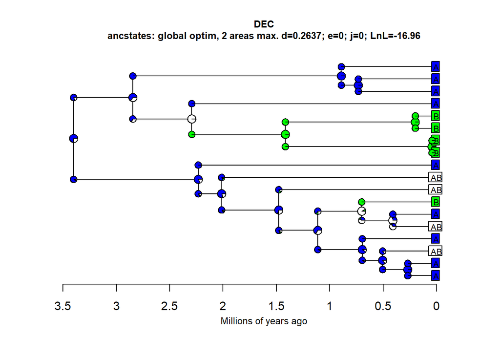

```
##         LnL nparams         d     e j
## 1 -16.95674       2 0.2636623 1e-12 0
```

```r
### DEC

analysis_titletxt ="DEC"
results_object = resDEC
scriptdir = np(system.file("extdata/a_scripts", package="BioGeoBEARS"))
tr = tree

plot_BioGeoBEARS_results(results_object, analysis_titletxt, addl_params=list("j"), plotwhat="pie", label.offset=0.45, tipcex=0.7, statecex=0.5, splitcex=0.4, titlecex=0.8, plotsplits=TRUE,  cornercoords_loc=scriptdir, include_null_range=T, tr=tr, show.tip.label = F, tipranges = NULL)
```

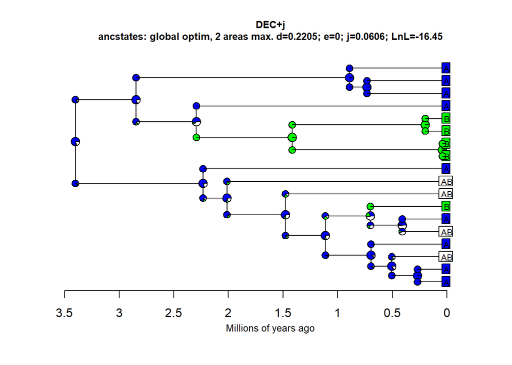

```
##         LnL nparams         d     e          j
## 1 -16.44873       3 0.2204575 1e-12 0.06058913
```

```r
### DEC+j

analysis_titletxt ="DEC+j"
results_object = resDECj
scriptdir = np(system.file("extdata/a_scripts", package="BioGeoBEARS"))
tr = tree

plot_BioGeoBEARS_results(results_object, analysis_titletxt, addl_params=list("j"), plotwhat="pie", label.offset=0.45, tipcex=0.7, statecex=0.5, splitcex=0.4, titlecex=0.8, plotsplits=TRUE,  cornercoords_loc=scriptdir, include_null_range=T, tr=tr, show.tip.label = F, tipranges = NULL)
```

### Statistics

Gerar uma tabela com as estimativas dos parâmetros, log-likelihood e AIC.

```r
restable = NULL
teststable = NULL

# DEC, null model for Likelihood Ratio Test (LRT)
# DEC+J, alternative model for Likelihood Ratio Test (LRT)

LnL_2 = get_LnL_from_BioGeoBEARS_results_object(resDEC)
LnL_1 = get_LnL_from_BioGeoBEARS_results_object(resDECj)

numparams1 = 3
numparams2 = 2
stats = AICstats_2models(LnL_1, LnL_2, numparams1, numparams2)

res2 = extract_params_from_BioGeoBEARS_results_object(results_object=resDEC, returnwhat="table", addl_params=c("j"), paramsstr_digits=4)
res1 = extract_params_from_BioGeoBEARS_results_object(results_object=resDECj, returnwhat="table", addl_params=c("j"), paramsstr_digits=4)
tmp_tests = conditional_format_table(stats)

restable = rbind(restable, res2, res1)
teststable = rbind(teststable, tmp_tests)
row.names(restable) = c("DEC", "DEC+J")
teststable$alt = "DEC+J"
teststable$null = "DEC"
restable$AIC <- c(teststable$AIC2, teststable$AIC1)

restable
```

```
##             LnL numparams         d     e          j   AIC
## DEC   -16.95674         2 0.2636623 1e-12 0.00000000 37.91
## DEC+J -16.44873         3 0.2204575 1e-12 0.06058913  38.9
```

```r
### Exportar
write.table(as.matrix(restable), file="Lychnophora_biogeo_pars_AIC.txt")
```

### Plot customizado

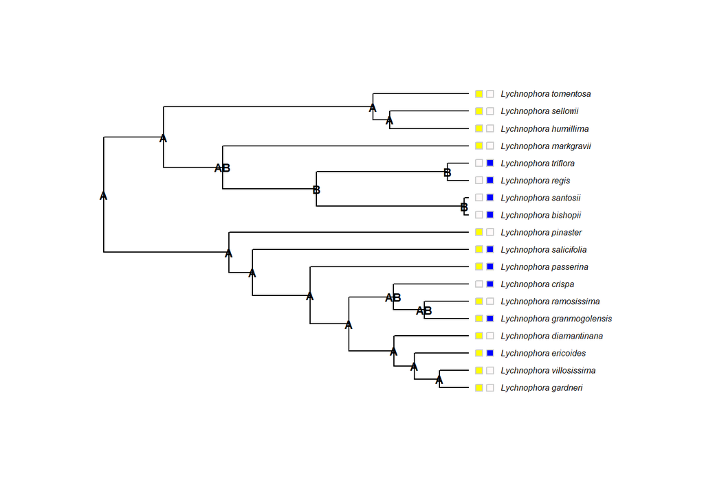

```r
data(gradstein04)
resDEC -> biogeo

areas.labels <- c("Espinhaço", "Diamantina")

lyc.mat -> tipStates

for (i in 1:ncol(tipStates)) {
  tipStates[,i] -> tip0
  tip0[tip0 == 1] <-  area.cols[i]
  tip0[tip0 == 0] <- "snow"
  tipStates[,i] <- tip0
}

tipranges = getranges_from_LagrangePHYLIP(lgdata_fn=geogfn)
areas.labs = getareas_from_tipranges_object(tipranges)
statenames = areas_list_to_states_list_new(areas.labs, maxareas = max_range_size, include_null_range = T, split_ABC = FALSE)
relprobs_matrix = biogeo$ML_marginal_prob_each_state_at_branch_top_AT_node
MLstates = get_ML_states_from_relprobs(relprobs_matrix, statenames, returnwhat = "states", if_ties = "takefirst")
Ntip(tree) -> n.tips
Nnode(tree) -> n.nodes
c((n.tips++1):(n.tips++n.nodes)) -> nodes
MLstates[nodes] -> node.states
alpha("gray50", 0.8) -> colorRanges
legend.col <- c(area.cols, colorRanges)
legend.txt <- c(areas.labels, "Widespread")

### pies

unlist(statenames) -> pie.colors
for (i in 1:length(pie.colors)) {
  pie.colors[i] -> col0
  nchar(col0) -> nn
  if(nn > 1) {
    col0 <- colorRanges
  } else {
    match(col0, areas.labs) -> nnn
    col0 <- area.cols[nnn]
  }
  pie.colors[i] <- col0
}

pie.data <- relprobs_matrix[nodes,]


### Plot

plot(tree, label.offset = 0.3, no.margin = F, cex = 0.5, show.tip.label=T, x.lim=5)
tiplabels(pch = 22, cex=1, bg = tipStates[,1], adj = 0.6, col="gray80")
tiplabels(pch = 22, cex=1, bg = tipStates[,2], adj = 0.7, col="gray80")
nodelabels(node.states, frame="none", cex=0.7, font=2)
```

```r
plot(tree, label.offset = 0.3, no.margin = F, cex = 0.5, show.tip.label=T, x.lim=5)
tiplabels(pch = 22, cex=1, bg = tipStates[,1], adj = 0.6, col="gray80")
tiplabels(pch = 22, cex=1, bg = tipStates[,2], adj = 0.7, col="gray80")
nodelabels(pie=pie.data, piecol=pie.colors, cex = 0.8)
axisGeo(GTS = gradstein04, unit = "epoch", col = c("grey80","white"), gridty=3, cex=0.5)
```

```
##
## Plot unit: epoch
## Stage 1: Holocene
## Stage 2: Pleistocene
## Stage 3: Pliocene
```

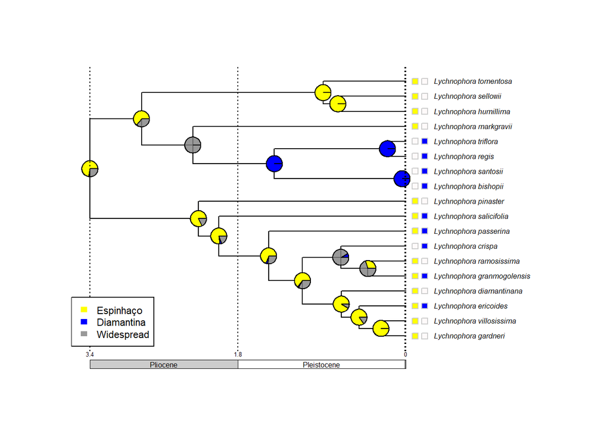

```r
legend("bottomleft", legend=legend.txt, border="white", fill=legend.col, cex=0.7)
```

Exportar

```r
pdf("Lychnophora_DEC.pdf", width=8.5, height=11)
plot(tree, label.offset = 0.3, no.margin = F, cex = 0.5, show.tip.label=T, x.lim=5)
tiplabels(pch = 22, cex=1, bg = tipStates[,1], adj = 0.6, col="gray80")
tiplabels(pch = 22, cex=1, bg = tipStates[,2], adj = 0.7, col="gray80")
nodelabels(pie=pie.data, piecol=pie.colors, cex = 0.8)
axisGeo(GTS = gradstein04, unit = "epoch", col = c("grey80","white"), gridty=3, cex=0.5)
legend("bottomleft", legend=legend.txt, border="white", fill=legend.col, cex=0.7)
dev.off()
```

## Age range correlation

Para rodar essa análise é preciso primeiro estimar uma matriz de overlap entre todas as espécies da amostra. Para detalhes sobre a análise ver:

[Fitzpatrick & Turelli 2006](https://onlinelibrary.wiley.com/doi/abs/10.1111/j.0014-3820.2006.tb01140.x)

### Range Overlap

Para utilizar esta função, dentre outras opções, é preciso fornecer um vetor com nomes de arquivos raster para cada espécie em formato “asc”.

```r
out_asc <- "~/Post-doc-Unicamp/Bioinformatica/Aulas/9 - BiogeoBEARS/Binaries"

### Criar uma mask (raster)

raster(res=0.05) -> r
r[] <- 1
crop(r, lyc.mask) -> r
mask(r, lyc.mask) -> r

### Gerar binarios em formato raster

setwd(out_asc)

for (i in 1:nrow(shapes)) {
  rasterize(shapes[i,], r) -> r0
  r0[is.na(r0)] <- 0
  writeRaster(r0, sub(" ", "_", paste(shapes$spp[i], ".asc", sep="")))
}


### Matriz de overlap

list.files(pattern=".asc") -> b.files

niche.overlap(b.files) -> lyc.ro
round(lyc.ro, 3) -> lyc.ro

### Acertar os nomes

sub(".asc", "", colnames(lyc.ro)) -> colnames(lyc.ro)
sub(".asc", "", rownames(lyc.ro)) -> rownames(lyc.ro)

setwd(wd)
```

### age.range.correlation

Rodar (com um n pequeno só para agilizar o processo)

```r
age.range.correlation(tree, overlap=lyc.ro, tri = "lower", n = 100) -> lyc.age.corr
```

Plotar

```r
# plot average niche overlap versus node age
plot(lyc.age.corr$age.range.correlation)
# add a regression line
abline(lyc.age.corr$linear.regression$coefficients)
# add regression lines from Monte Carlo randomization
apply(lyc.age.corr$MonteCarlo.replicates, 1, abline, lwd = 0.2, col = "grey90")
```

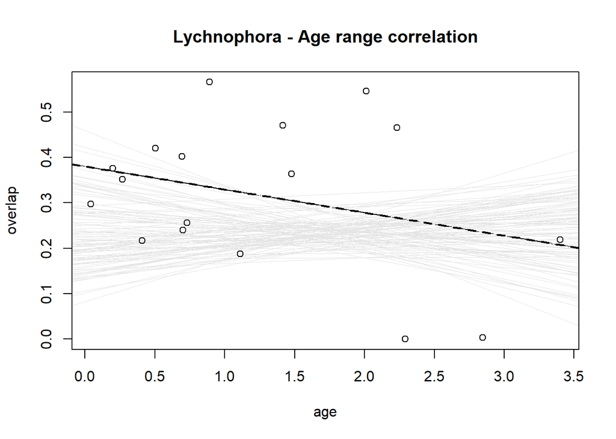

```r
points(lyc.age.corr$age.range.correlation)
abline(lyc.age.corr$linear.regression$coefficients, lwd=2, lty="dashed")
box()
title("Lychnophora - Age range correlation")
```

```r
lyc.age.corr$sig
```

```
##                f    p
## (intercept) 0.04 0.08
## age         0.83 0.34
```

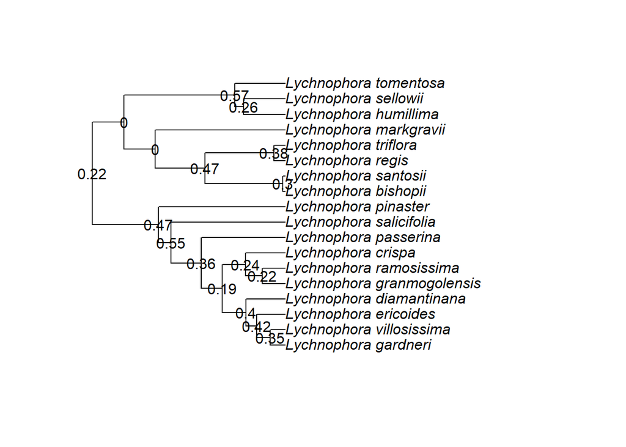

```r
### Plotar o overlap (contrastes)

plot(tree)
nodelabels(round(lyc.age.corr$age.range.correlation[,2],2), frame="none")
```

### Por clado

```r
### Clado A

phyloch::descendants(tree, node=29, labels=T) -> spp.A
extract.clade(tree, node = 29) -> tree.A

paste(sub(" ", "_", spp.A), ".asc", sep="") -> files.A

### Matriz de overlap

setwd(out_asc)

niche.overlap(files.A) -> ro.A
round(ro.A, 3) -> ro.A

### Acertar os nomes

sub(".asc", "", colnames(ro.A)) -> colnames(ro.A)
sub(".asc", "", rownames(ro.A)) -> rownames(ro.A)

setwd(wd)

### rodar

age.range.correlation(tree.A, overlap=ro.A, tri = "lower", n = 100) -> lyc.age.A

### plotar

plot(lyc.age.A$age.range.correlation)
abline(lyc.age.A$linear.regression$coefficients)
apply(lyc.age.A$MonteCarlo.replicates, 1, abline, lwd = 0.2, col = "grey90")
```

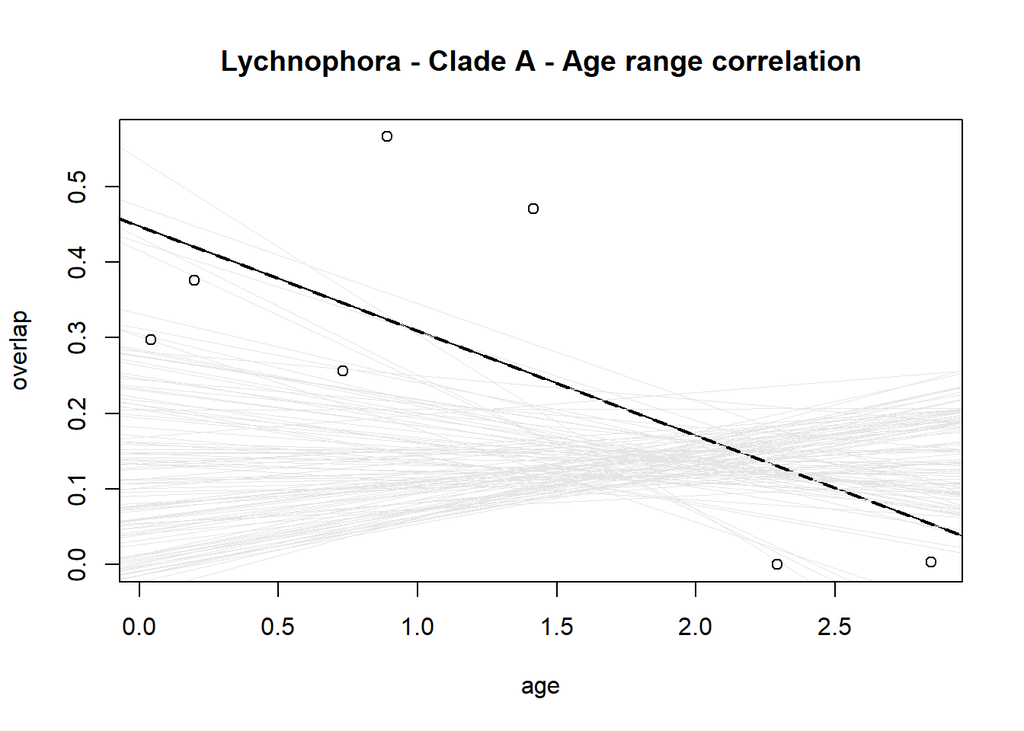

```r
points(lyc.age.A$age.range.correlation)
abline(lyc.age.A$linear.regression$coefficients, lwd=2, lty="dashed")
box()
title("Lychnophora - Clade A - Age range correlation")
```

```r
lyc.age.A$sig
```

```
##                f    p
## (intercept) 0.02 0.04
## age         0.97 0.06
```

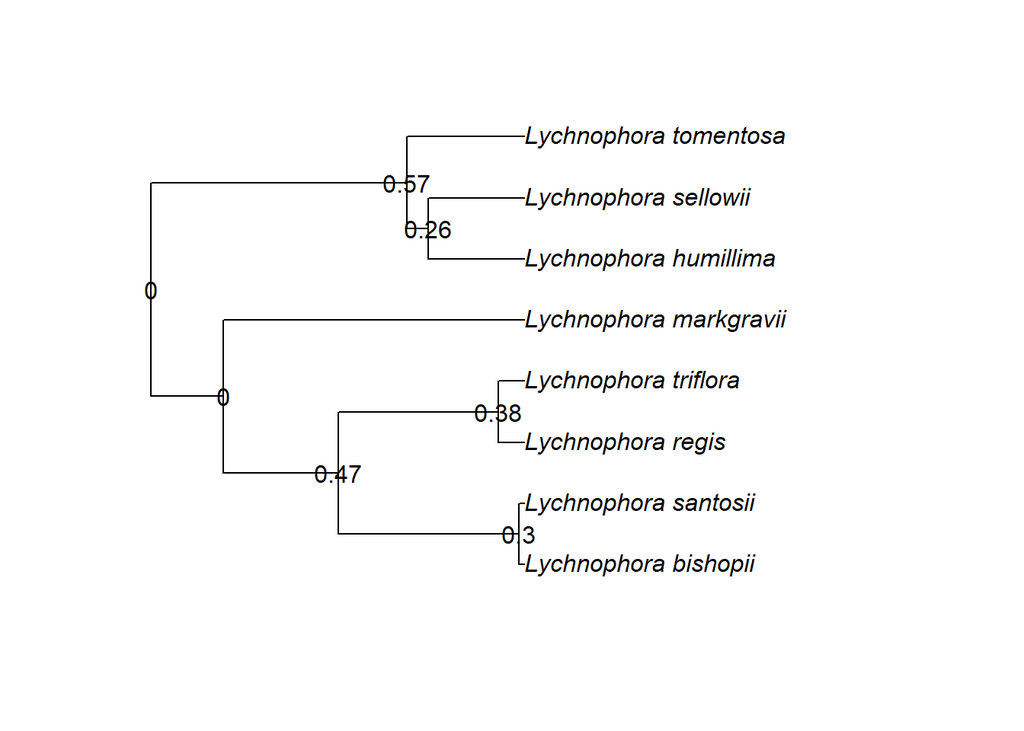

```r
### Plotar o overlap (contrastes)

plot(tree.A)
nodelabels(round(lyc.age.A$age.range.correlation[,2],2), frame="none")
```

Tentem fazer para o clado B!!!